# Hayman Fire Recovery

Keian Freshwater

03 February, 2022

**Library set-up for the document:**

```r
library(tidyverse)
library(tidyr)
library(ggthemes)
library(lubridate)

# Now that we have learned how to munge (manipulate) data
# and plot it, we will work on using these skills in new ways

knitr::opts_knit$set(root.dir='..')
```

**Reading in Selected Datasets:**

```r
####-----Reading in Data and Stacking it ----- ####
#Reading in files
files <- list.files('data/original',full.names=T)


#Read in individual data files
ndmi <- read_csv(files[1]) %>%
  rename(burned=2,unburned=3) %>%
  mutate(data='ndmi')


ndsi <- read_csv(files[2]) %>%
  rename(burned=2,unburned=3) %>%
  mutate(data='ndsi')

ndvi <- read_csv(files[3])%>%
  rename(burned=2,unburned=3) %>%
  mutate(data='ndvi')

# Stack as a tidy dataset
full_long <- rbind(ndvi,ndmi,ndsi) %>%
  gather(key='site',value='value',-DateTime,-data) %>%
  filter(!is.na(value))
```

## Question 1

### Correlation between NDVI and NDMI, using a wide dataset. Data is between 1984-2019, and focuses on summer months (Jun-Sept):

```r
full_wide <- spread(full_long,data,value) %>%
    mutate(month=month(DateTime),
           year=year(DateTime)) %>%
    filter(month %in% c(6,7,8,9))
```

**Plotting the Correlation between NDVI and NDMI:**

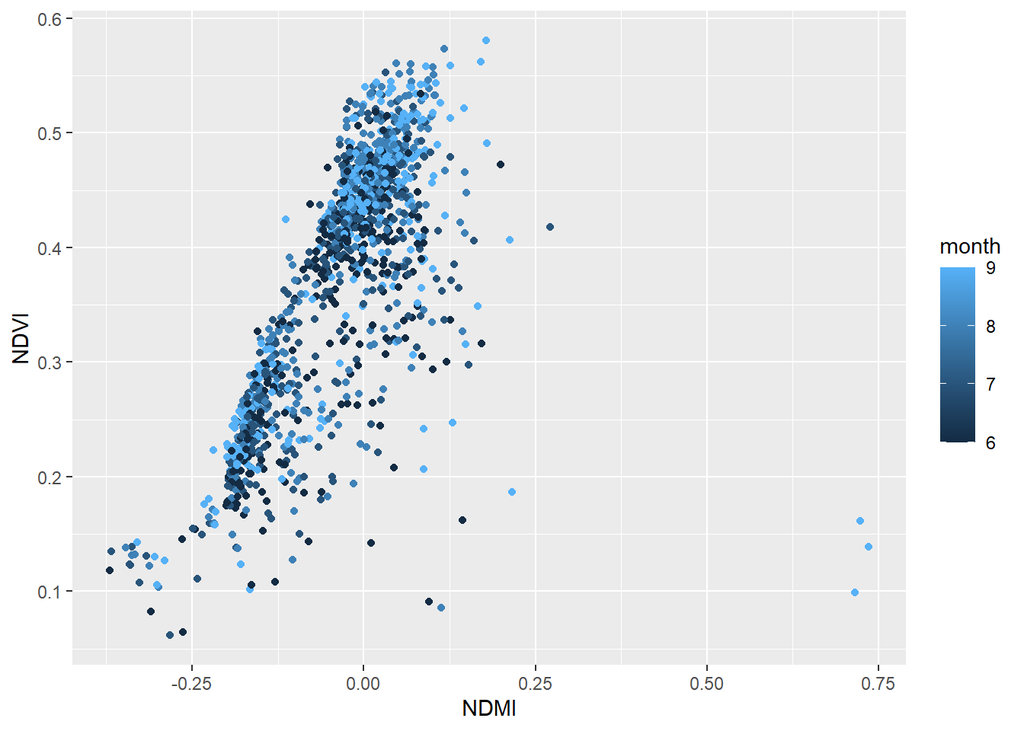

```r
ggplot(data=full_wide,aes(x=ndmi,y=ndvi, color=month)) +
       geom_point() +
       xlab('NDMI') +
       ylab ('NDVI')
```

## Question 2

### Correlation between average NDSI (normalized snow index) for January - April and average NDVI for June-August. Does the previous year’s snow cover influence vegetation growth for the following summer?

**Creating a clean data set containing relevant averages:**

```r
full_wide_full <- spread(full_long,data,value) %>%
  mutate(month=month(DateTime),
           year=year(DateTime)) %>%
  group_by(site,year)
```

```r
full_wide_average_summer <- full_wide_full  %>%
  filter(month %in% c(6,7,8))%>%
  group_by(year) %>%
  summarize(mean_NDVI_summer = mean(ndvi,na.rm=TRUE))
```

```r
full_wide_average_spring <- full_wide_full  %>%
  filter(month %in% c(1,2,3,4))%>%
  group_by(year) %>%
  summarize(mean_NDSI_spring = mean(ndsi,na.rm=TRUE))
```

```r
full_wide_average <- inner_join(full_wide_average_spring,full_wide_average_summer)
```

**Plotting the Correlation between average summer NDVI and average spring NDSI:**

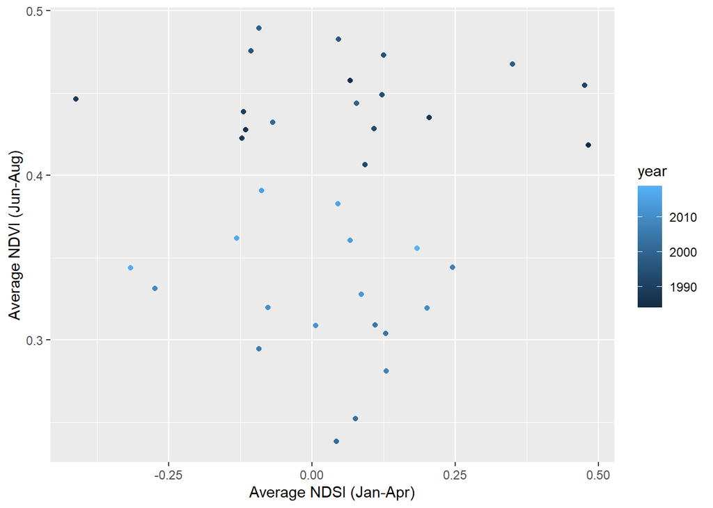

```r
ggplot(data=full_wide_average,aes(x=mean_NDSI_spring,y=mean_NDVI_summer, color=year)) +
       geom_point() +
       xlab('Average NDSI (Jan-Apr)') +
       ylab ('Average NDVI (Jun-Aug)')
```

There is little correlation between average spring NDSI and average summer NDVI; if generous, there might be a weak positive correlation. Overall, the most notable pattern is that, for roughly the same range of NDSI, the average summer NDVI is, generally, lower in the 2010s compared to the 1990s.

## Q3

### How is the snow effect from question 2 different between pre- and post-burn and burned and unburned?

**Filter by Burned/Unburned:**

```r
full_wide_unburned <- full_wide_full  %>%
  filter(site %in% c('unburned'))
full_wide_burned <- full_wide_full  %>%
  filter(site %in% c('burned'))
```

**Filter and Graph Unburned average summer NDVI and average spring NDSI:**

```r
full_wide_unburned_average_summer <- full_wide_unburned  %>%
  filter(month %in% c(6,7,8))%>%
  group_by(year) %>%
  summarize(mean_NDVI_summer = mean(ndvi,na.rm=TRUE))
```

```r
full_wide_unburned_average_spring <- full_wide_unburned  %>%
  filter(month %in% c(1,2,3,4))%>%
  group_by(year) %>%
  summarize(mean_NDSI_spring = mean(ndsi,na.rm=TRUE))
```

```r
full_wide_average_unburned <- inner_join(full_wide_unburned_average_spring,full_wide_unburned_average_summer)
```

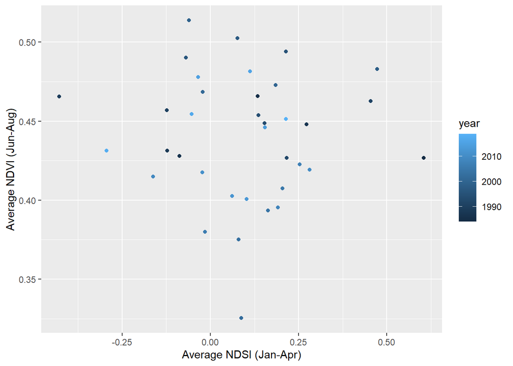

```r
ggplot(data=full_wide_average_unburned,aes(x=mean_NDSI_spring,y=mean_NDVI_summer, color=year)) +
       geom_point() +
       xlab('Average NDSI (Jan-Apr)') +
       ylab ('Average NDVI (Jun-Aug)')
```

The unburned graph supports the identical conclusion as problem 2; there is little (at most, weak positive) correlation between Average Spring NDSI and Average Summer NDVI.

**Filter and Graph Burned average summer NDVI and average spring NDSI:**

```r
full_wide_burned_average_summer <- full_wide_burned  %>%
  filter(month %in% c(6,7,8))%>%
  group_by(year) %>%
  summarize(mean_NDVI_summer = mean(ndvi,na.rm=TRUE))
```

```r
full_wide_burned_average_spring <- full_wide_burned  %>%
  filter(month %in% c(1,2,3,4))%>%
  group_by(year) %>%
  summarize(mean_NDSI_spring = mean(ndsi,na.rm=TRUE))
```

```r
full_wide_average_burned <- inner_join(full_wide_burned_average_summer,full_wide_burned_average_spring)
```

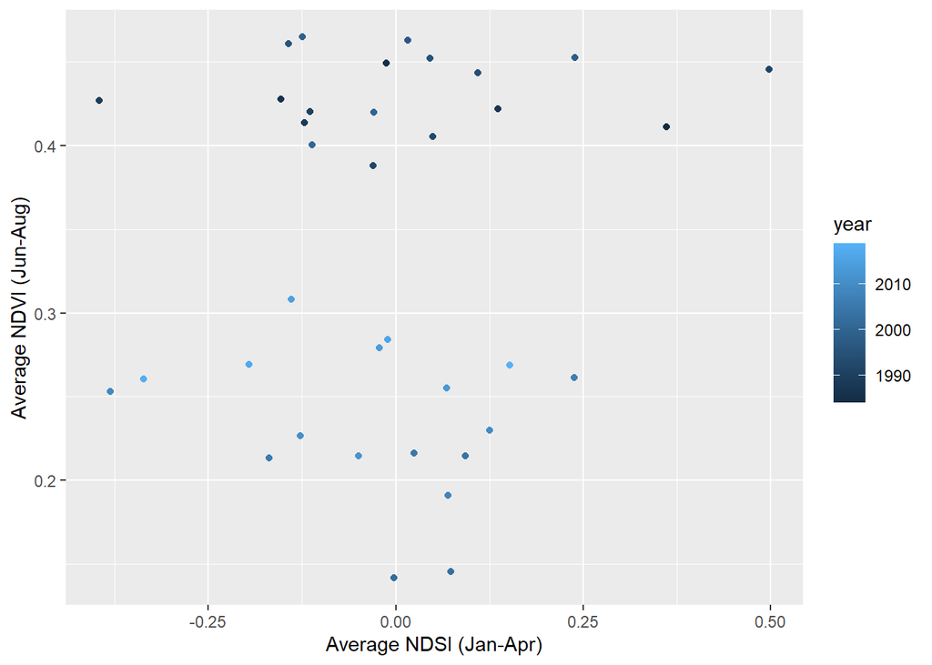

```r
ggplot(data=full_wide_average_burned,aes(x=mean_NDSI_spring,y=mean_NDVI_summer, color=year)) +
       geom_point() +
       xlab('Average NDSI (Jan-Apr)') +
       ylab ('Average NDVI (Jun-Aug)')
```

In the 1980s and 1990s, the burned areas had exclusively high NDVI regardless of of NDSI, while the 2000s and 2010s had comparatively low NDVI regardless of NDSI.

## Question 4

**For the following questions:**

```r
full_wide_jan <- full_wide_full  %>%
  filter(month %in% c(1)) %>%
  group_by(month) %>%
  select(-DateTime,-site,-year)
full_wide_feb <- full_wide_full  %>%
  filter(month %in% c(2)) %>%
  group_by(month) %>%
  select(-DateTime,-site,-year)
full_wide_mar <- full_wide_full  %>%
  filter(month %in% c(3)) %>%
  group_by(month) %>%
  select(-DateTime,-site,-year)
full_wide_apr <- full_wide_full  %>%
  filter(month %in% c(4)) %>%
  group_by(month) %>%
  select(-DateTime,-site,-year)
full_wide_may <- full_wide_full  %>%
  filter(month %in% c(5)) %>%
  group_by(month) %>%
  select(-DateTime,-site,-year)
full_wide_jun <- full_wide_full  %>%
  filter(month %in% c(6)) %>%
  group_by(month) %>%
  select(-DateTime,-site,-year)
full_wide_jul <- full_wide_full  %>%
  filter(month %in% c(7)) %>%
  select(-DateTime) %>%
  group_by(year,ndvi,ndmi,ndsi)
full_wide_aug <- full_wide_full  %>%
  filter(month %in% c(8)) %>%
  group_by(month) %>%
  select(-DateTime,-site,-year)
full_wide_sept <- full_wide_full  %>%
  filter(month %in% c(9)) %>%
  group_by(month) %>%
  select(-DateTime,-site,-year)
full_wide_oct <- full_wide_full  %>%
 filter(month %in% c(10)) %>%
  group_by(month) %>%
  select(-DateTime,-site,-year)
full_wide_nov <- full_wide_full  %>%
  filter(month %in% c(11)) %>%
  group_by(month) %>%
  select(-DateTime,-site,-year)
full_wide_dec <- full_wide_full  %>%
  filter(month %in% c(12)) %>%
  group_by(month) %>%
  select(-DateTime,-site,-year)
```

### What month is the greenest month on average?

**Calculate Averages for NDVI:**

```r
jan_NDVI <- mean(full_wide_jan$ndvi,na.rm=TRUE)
feb_NDVI <- mean(full_wide_feb$ndvi,na.rm=TRUE)
mar_NDVI <- mean(full_wide_mar$ndvi,na.rm=TRUE)
apr_NDVI <- mean(full_wide_apr$ndvi,na.rm=TRUE)
may_NDVI <- mean(full_wide_may$ndvi,na.rm=TRUE)
jun_NDVI <- mean(full_wide_jun$ndvi,na.rm=TRUE)
jul_NDVI <- mean(full_wide_jul$ndvi,na.rm=TRUE)
aug_NDVI <- mean(full_wide_aug$ndvi,na.rm=TRUE)
sept_NDVI <- mean(full_wide_sept$ndvi,na.rm=TRUE)
oct_NDVI <- mean(full_wide_oct$ndvi,na.rm=TRUE)
nov_NDVI <- mean(full_wide_nov$ndvi,na.rm=TRUE)
dec_NDVI <- mean(full_wide_dec$ndvi,na.rm=TRUE)
```

**Organize in Table:**

```r
green_NVDI <- rbind.data.frame(jan_NDVI,feb_NDVI,mar_NDVI,apr_NDVI,may_NDVI,jun_NDVI,jul_NDVI,aug_NDVI,sept_NDVI,oct_NDVI,nov_NDVI,dec_NDVI)
greenest_month <- max(green_NVDI)
```

NDVI stands for ‘Normalized Difference Vegetation Index’, where the highest NDVI will indicate the greenest month on average. The greenest month is August, with an average NDVI of 0.3871568.

## Question 5

### What month is the snowiest on average?

**Calculate Averages for NDVI:**

```r
jan_NDSI <- mean(full_wide_jan$ndsi,na.rm=TRUE)
feb_NDSI <- mean(full_wide_feb$ndsi,na.rm=TRUE)
mar_NDSI <- mean(full_wide_mar$ndsi,na.rm=TRUE)
apr_NDSI <- mean(full_wide_apr$ndsi,na.rm=TRUE)
may_NDSI <- mean(full_wide_may$ndsi,na.rm=TRUE)
jun_NDSI <- mean(full_wide_jun$ndsi,na.rm=TRUE)
jul_NDSI <- mean(full_wide_jul$ndsi,na.rm=TRUE)
aug_NDSI <- mean(full_wide_aug$ndsi,na.rm=TRUE)
sept_NDSI <- mean(full_wide_sept$ndsi,na.rm=TRUE)
oct_NDSI <- mean(full_wide_oct$ndsi,na.rm=TRUE)
nov_NDSI <- mean(full_wide_nov$ndsi,na.rm=TRUE)
dec_NDSI <- mean(full_wide_dec$ndsi,na.rm=TRUE)
```

**Organize in Table:**

```r
snow_NDSI <- rbind.data.frame(jan_NDSI,feb_NDSI,mar_NDSI,apr_NDSI,may_NDSI,jun_NDSI,jul_NDSI,aug_NDSI,sept_NDSI,oct_NDSI,nov_NDSI,dec_NDSI)
snowiest_month <- max(snow_NDSI)
```

NDSI stands for ‘Normalized Difference Snow Index’, where the highest NDSI will indicate the snowiest month on average. The snowiest month is January, with an average NDSI of 0.2099584.

## Bonus Question: Redo all problems with `spread` and `gather` using modern tidyverse syntax.

### Note: Completion of Problem 1 only:

#### Problem 1:

```r
full_wide_pivot_bonus_1 <- full_long %>%
  pivot_wider(id_cols= NULL, names_from = "data", values_from = "value") %>%
  mutate(month=month(DateTime),
           year=year(DateTime))  %>%
  filter(month %in% c(6,7,8,9))
```

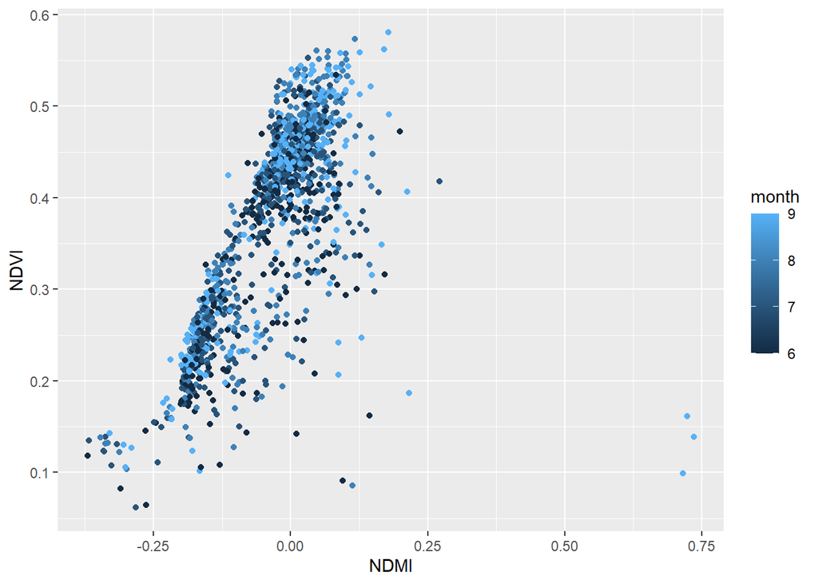

```r
ggplot(data=full_wide_pivot_bonus_1,aes(x=ndmi,y=ndvi, color=month)) +
       geom_point() +
       xlab('NDMI') +
       ylab ('NDVI')
```

# Bonus Question: Use Climage Engine to pull the same data for the assignment, but updated with 2020/2021 data.

[Link to a new page updated for remaining 2019 and new 2020/2021 data sets.](https://kfreshwater.github.io/2_fire_data_wrangle/src/Hayman-Fire-Recovery-Assignment-2---2021-Update.html)